# PIBIC_Research

Bruno Dalben

2025-05-15

## Objective

Understand the impacts of AI usage on the brazilian job market using the AIOE measures by Felten paper: https://sms.onlinelibrary.wiley.com/doi/full/10.1002/smj.3286#support-information-section

## Libraries Used

PNADcIBGE for getting data from IBGE, duckdb for using SQL queries for performance gains and smaller code, write and read xl for manipulating excel sheets

```r
library(PNADcIBGE)
library(duckdb)
library(writexl)
library(readxl)
library(sets)
library(kableExtra)
library(gridExtra)
```

## Extracting the data

Creating a Function to automatically read PNAD from given year and quarter and upload it do SQL connection:

```r
con <- dbConnect(duckdb())
db_get_pnad <- function(name, year, quarter, vars=NULL){
  dados <- get_pnadc(year = year, quarter = quarter, vars = vars, design=F)
  dbWriteTable(con, name, dados, overwrite = T)
}
```

Extracting appendix Matrix from Felten Paper, as well as the crosswalk where I list each ability level and importance in accordance to the brazilian ocupation classification (ISCO-08)(I couldn’t find the original code in which I did the crosswalk, so I connected directly to the results table I uploaded to GitHub):

```r
url <- "https://github.com/AIOE-Data/AIOE/raw/refs/heads/main/AIOE_DataAppendix.xlsx"
destfile <- "AIOE_DataAppendix.xlsx"
curl::curl_download(url, destfile)
Ap_Matrix <- read_excel(destfile,
    sheet = 5)
Ap_Matrix[['Exposure']] <- rowSums(Ap_Matrix[, 2:ncol(Ap_Matrix)])
url <- "https://github.com/BDalben/PIBIC-Files/raw/refs/heads/main/ISCOAB.xlsx"
destfile <- "ISCOAB.xlsx"
curl::curl_download(url, destfile)
isco_abilities <- read_excel(destfile)
dbWriteTable(con, 'Ap_Matrix', Ap_Matrix, overwrite = T)
dbWriteTable(con, 'isco_abilities', isco_abilities, overwrite = T)
ab_exposure_table <- dbGetQuery(con, 'SELECT "...1" AS ability, Exposure FROM Ap_Matrix' )
```

## Calculating AIOE (AI Ocupational Exposure)

Calculating the AIOE for each ocuppation:

```r
stopifnot(as.set(ab_exposure_table$ability) == as.set(Ap_Matrix$...1))
AIOE_isco_table <- dbGetQuery(con, "WITH a AS (SELECT preferredLabel AS label, \"isco08\",  \"Element Name\", value AS lev FROM isco_abilities WHERE \"Scale Name\" = 'Level'),
                                   b AS (SELECT preferredLabel AS label, \"isco08\",  \"Element Name\", value AS imp FROM isco_abilities WHERE \"Scale Name\" = 'Importance'),
                                   better_form AS (SELECT a.label, a.\"isco08\", a.\"Element Name\", lev, imp FROM a INNER JOIN b ON a.label = b.label AND a.\"Element Name\" = b.\"Element Name\"),
                                   c AS (SELECT label, \"isco08\",  \"Element Name\", lev, imp, Exposure AS exp FROM better_form INNER JOIN Ap_Matrix ON \"...1\"= \"Element Name\")
                                   SELECT label, \"isco08\", ROUND(SUM(lev*imp*exp)/SUM(lev*imp),2) AS AIOE FROM c GROUP BY \"isco08\", label ORDER BY AIOE DESC")
dbWriteTable(con, 'AIOE_isco_table', AIOE_isco_table, overwrite = T)
```

Adding an AIOE column to the PNAD data frame:

```r
#Dicionário: V4010: código ocupação; V403312: rendimento bruto mensal; V1023: tipo de área (Capital, periferia ... ). V4029: tinha carteira
db_get_pnad('pnad_2024.4', 2024, 4)
pnad_2024.4_AIOE <- dbGetQuery(con, 'SELECT UF, V1023, V1022, V4029, V4010, AIOE, V403312, V2007, V3007, V3009A, V2009, label FROM "pnad_2024.4" INNER JOIN AIOE_isco_table ON "V4010" ="isco08"')
dbWriteTable(con, 'pnad_2024.4_AIOE', pnad_2024.4_AIOE, overwrite = T)
```

## Creating filtered df’s

```r
pnad_2024.4_formal <- dbGetQuery(con, 'SELECT * FROM "pnad_2024.4_AIOE" WHERE NOT "V4029" IS NULL')
pnad_2024.4_informal <- dbGetQuery(con, 'SELECT * FROM "pnad_2024.4_AIOE" WHERE "V4029" IS NULL')
pnad_2024.4_capitals <- dbGetQuery(con, 'SELECT * FROM "pnad_2024.4_AIOE" WHERE "V1023" = \'Capital\'')
pnad_2024.4_not_cap <- dbGetQuery(con, 'SELECT * FROM "pnad_2024.4_AIOE" WHERE NOT "V1023" = \'Capital\'')
```

## Means By State

```r
pnad_2024.4_AIOE_mean_by_state <- dbGetQuery(con, 'SELECT UF, MEAN(AIOE) AS AIOE_mean, MEAN(v403312) AS salary_mean, count(V4029)/count(v4010) as formal_share, COUNT(CASE WHEN "V2007"=\'Homem\' THEN \'T\' ELSE NULL END)/ COUNT(V2007) AS male_share, MEAN(V2009) AS mean_age, COUNT(CASE WHEN V3009A = \'Superior - graduação\' OR V3009A = \'Especialização de nível superior\' OR V3009A = \'Mestrado\' OR V3009A = \'Doutorado\' THEN \'T\' ELSE NULL END)/COUNT(V3009A) AS college_share FROM "pnad_2024.4_AIOE" GROUP BY UF ORDER BY UF')
kable(pnad_2024.4_AIOE_mean_by_state)
```

| UF | AIOE_mean | salary_mean | formal_share | male_share | mean_age | college_share |
| --- | --- | --- | --- | --- | --- | --- |
| Rondônia | 5.833141 | 2919.090 | 0.4175178 | 0.6168369 | 41.75487 | 0.1903303 |
| Acre | 5.877757 | 2470.123 | 0.5737653 | 0.6055363 | 39.80371 | 0.2617426 |
| Amazonas | 5.844931 | 2147.360 | 0.4440249 | 0.5839154 | 39.28110 | 0.2059656 |
| Roraima | 5.873113 | 2684.347 | 0.5440742 | 0.5811894 | 39.28300 | 0.2710815 |
| Pará | 5.826803 | 2222.328 | 0.5133256 | 0.6048667 | 40.21017 | 0.1782096 |
| Amapá | 5.929079 | 2795.310 | 0.4958678 | 0.5554900 | 39.93447 | 0.3368490 |
| Tocantins | 5.871614 | 2664.418 | 0.5885922 | 0.5922330 | 40.96845 | 0.2541012 |
| Maranhão | 5.834587 | 1762.289 | 0.5147191 | 0.5963477 | 39.77437 | 0.1641111 |
| Piauí | 5.836952 | 1964.438 | 0.5590728 | 0.5742772 | 41.65404 | 0.2108078 |
| Ceará | 5.857376 | 1949.023 | 0.5782467 | 0.5685757 | 41.15021 | 0.1837505 |
| Rio Grande do Norte | 5.880383 | 2318.768 | 0.5933937 | 0.5893014 | 41.11517 | 0.2223650 |
| Paraíba | 5.855314 | 2173.618 | 0.5784583 | 0.5822598 | 40.96325 | 0.2120224 |
| Pernambuco | 5.837360 | 2255.126 | 0.5917843 | 0.5768079 | 40.74155 | 0.2097607 |
| Alagoas | 5.833202 | 2105.358 | 0.6303640 | 0.5833087 | 39.53936 | 0.2083403 |
| Sergipe | 5.822794 | 2110.350 | 0.5893926 | 0.5834046 | 40.12546 | 0.1924647 |
| Bahia | 5.799660 | 1847.610 | 0.5794590 | 0.5802787 | 41.32592 | 0.1606218 |
| Minas Gerais | 5.832733 | 2744.576 | 0.6164947 | 0.5705601 | 41.56749 | 0.2156517 |
| Espírito Santo | 5.883113 | 3072.555 | 0.5914797 | 0.5584936 | 41.69925 | 0.2525431 |
| Rio de Janeiro | 5.984615 | 3452.653 | 0.5918625 | 0.5252894 | 43.25142 | 0.3245409 |
| São Paulo | 5.939284 | 3811.016 | 0.6388477 | 0.5462642 | 41.96256 | 0.3153246 |
| Paraná | 5.872868 | 3409.940 | 0.6050139 | 0.5592030 | 41.18496 | 0.2579697 |
| Santa Catarina | 5.890864 | 3685.021 | 0.6052948 | 0.5419842 | 39.92365 | 0.2721392 |
| Rio Grande do Sul | 5.893626 | 3595.955 | 0.5562197 | 0.5422456 | 43.05145 | 0.2775734 |
| Mato Grosso do Sul | 5.862892 | 3209.859 | 0.6236649 | 0.5545550 | 41.46157 | 0.2762535 |
| Mato Grosso | 5.860832 | 3365.804 | 0.6203044 | 0.5795013 | 40.36869 | 0.2424353 |
| Goiás | 5.867307 | 3168.575 | 0.6211057 | 0.5651598 | 41.40196 | 0.2461538 |
| Distrito Federal | 6.025062 | 4584.648 | 0.6340437 | 0.5153907 | 40.60879 | 0.4199578 |

```r
pnad_2024.4_AIOE_mean_by_state_round <- dbGetQuery(con, 'SELECT UF, ROUND(MEAN(AIOE),2) AS AIOE_mean, ROUND(MEAN(v403312),2) AS salary_mean, ROUND(count(V4029)/count(v4010), 2) as formal_share, ROUND(COUNT(CASE WHEN "V2007"=\'Homem\' THEN \'T\' ELSE NULL END)/ COUNT(V2007), 2) AS male_share, ROUND(MEAN(V2009), 2) AS mean_age, ROUND(COUNT(CASE WHEN V3009A = \'Superior - graduação\' OR V3009A = \'Especialização de nível superior\' OR V3009A = \'Mestrado\' OR V3009A = \'Doutorado\' THEN \'T\' ELSE NULL END)/COUNT(V3009A), 2) AS college_share, COUNT(CASE WHEN V1022 = \'Urbana\' THEN \'T\' ELSE NULL END)/COUNT(V1022) AS urban_share FROM "pnad_2024.4_AIOE" GROUP BY UF ORDER BY UF')
kable(pnad_2024.4_AIOE_mean_by_state_round)
```

| UF | AIOE_mean | salary_mean | formal_share | male_share | mean_age | college_share | urban_share |
| --- | --- | --- | --- | --- | --- | --- | --- |
| Rondônia | 5.83 | 2919.09 | 0.42 | 0.62 | 41.75 | 0.19 | 0.6666667 |
| Acre | 5.88 | 2470.12 | 0.57 | 0.61 | 39.80 | 0.26 | 0.7514942 |
| Amazonas | 5.84 | 2147.36 | 0.44 | 0.58 | 39.28 | 0.21 | 0.7119124 |
| Roraima | 5.87 | 2684.35 | 0.54 | 0.58 | 39.28 | 0.27 | 0.7827921 |
| Pará | 5.83 | 2222.33 | 0.51 | 0.60 | 40.21 | 0.18 | 0.6522306 |
| Amapá | 5.93 | 2795.31 | 0.50 | 0.56 | 39.93 | 0.34 | 0.8896104 |
| Tocantins | 5.87 | 2664.42 | 0.59 | 0.59 | 40.97 | 0.25 | 0.7333131 |
| Maranhão | 5.83 | 1762.29 | 0.51 | 0.60 | 39.77 | 0.16 | 0.5718990 |
| Piauí | 5.84 | 1964.44 | 0.56 | 0.57 | 41.65 | 0.21 | 0.6692423 |
| Ceará | 5.86 | 1949.02 | 0.58 | 0.57 | 41.15 | 0.18 | 0.7277066 |
| Rio Grande do Norte | 5.88 | 2318.77 | 0.59 | 0.59 | 41.12 | 0.22 | 0.7889506 |
| Paraíba | 5.86 | 2173.62 | 0.58 | 0.58 | 40.96 | 0.21 | 0.7167899 |
| Pernambuco | 5.84 | 2255.13 | 0.59 | 0.58 | 40.74 | 0.21 | 0.7599487 |
| Alagoas | 5.83 | 2105.36 | 0.63 | 0.58 | 39.54 | 0.21 | 0.7210713 |
| Sergipe | 5.82 | 2110.35 | 0.59 | 0.58 | 40.13 | 0.19 | 0.6823496 |
| Bahia | 5.80 | 1847.61 | 0.58 | 0.58 | 41.33 | 0.16 | 0.6284108 |
| Minas Gerais | 5.83 | 2744.58 | 0.62 | 0.57 | 41.57 | 0.22 | 0.7607467 |
| Espírito Santo | 5.88 | 3072.56 | 0.59 | 0.56 | 41.70 | 0.25 | 0.7913996 |
| Rio de Janeiro | 5.98 | 3452.65 | 0.59 | 0.53 | 43.25 | 0.32 | 0.9294984 |
| São Paulo | 5.94 | 3811.02 | 0.64 | 0.55 | 41.96 | 0.32 | 0.8424872 |
| Paraná | 5.87 | 3409.94 | 0.61 | 0.56 | 41.18 | 0.26 | 0.7837661 |
| Santa Catarina | 5.89 | 3685.02 | 0.61 | 0.54 | 39.92 | 0.27 | 0.7954272 |
| Rio Grande do Sul | 5.89 | 3595.96 | 0.56 | 0.54 | 43.05 | 0.28 | 0.7455574 |
| Mato Grosso do Sul | 5.86 | 3209.86 | 0.62 | 0.55 | 41.46 | 0.28 | 0.8108901 |
| Mato Grosso | 5.86 | 3365.80 | 0.62 | 0.58 | 40.37 | 0.24 | 0.8021373 |
| Goiás | 5.87 | 3168.58 | 0.62 | 0.57 | 41.40 | 0.25 | 0.8349463 |
| Distrito Federal | 6.03 | 4584.65 | 0.63 | 0.52 | 40.61 | 0.42 | 0.9381742 |

```r
pnad_2024.4_largest_ocupation <- dbGetQuery(con, 'WITH a AS (SELECT UF, label, COUNT(label) AS qtd FROM "pnad_2024.4_AIOE" GROUP BY label, UF)
                                                  SELECT UF, ANY_VALUE(label) AS "maior ocupação", MAX(qtd) AS sample_level FROM a GROUP BY UF')
kable(pnad_2024.4_largest_ocupation[,c('UF', 'maior ocupação')])
```

| UF | maior ocupação |
| --- | --- |
| Rondônia | Electrical mechanics and fitters |
| Acre | Legal and related associate professionals |
| Amazonas | Primary school teachers |
| Roraima | Fitness and recreation instructors and program leaders |
| Pará | Sales workers not elsewhere classified |
| Amapá | Butchers, fishmongers and related food preparers |
| Tocantins | Crop farm labourers |
| Maranhão | Nursing professionals |
| Piauí | Domestic cleaners and helpers |
| Ceará | Receptionists (general) |
| Rio Grande do Norte | Restaurant managers |
| Paraíba | Building caretakers |
| Pernambuco | Building architects |
| Alagoas | Hairdressers |
| Sergipe | Shop supervisors |
| Bahia | Administrative and executive secretaries |
| Minas Gerais | Building caretakers |
| Espírito Santo | Butchers, fishmongers and related food preparers |
| Rio de Janeiro | Restaurant managers |
| São Paulo | Domestic cleaners and helpers |
| Paraná | Civil engineers |
| Santa Catarina | Psychologists |
| Rio Grande do Sul | Legal professionals not elsewhere classified |
| Mato Grosso do Sul | Cabinet-makers and related workers |
| Mato Grosso | Stock clerks |
| Goiás | Secretaries (general) |
| Distrito Federal | Accounting associate professionals |

## Plotting

```r
plot_brazil_map_full_names <- function(data_frame, state_col = "state", value_col = "aeio_mean", title = "AIOE Measures By Brazilian State 2024.4", limits = NULL) {
  if (!require(ggplot2)) install.packages("ggplot2")
  if (!require(geobr)) install.packages("geobr")
  if (!require(stringi)) install.packages("stringi")
  if (!require(dplyr)) install.packages("dplyr")
  library(ggplot2)
  library(geobr)
  library(stringi)
  library(dplyr)
  states <- geobr::read_state()
  states <- states %>%
    mutate(name_state_normalized = tolower(stringi::stri_trans_general(name_state, "Latin-ASCII")))
  data_frame <- data_frame %>%
    mutate(!!state_col := tolower(stringi::stri_trans_general(!!sym(state_col), "Latin-ASCII")))
  merged_data <- merge(states, data_frame, by.x = "name_state_normalized", by.y = state_col)
  ggplot() +
    geom_sf(data = merged_data, aes(fill = get(value_col)), color = "black", size = 0.2) +
    scale_fill_gradient(low = "lightblue", high = "darkblue", name = value_col, limits=limits) +
    theme_minimal() +
    labs(title=title) +
    theme(legend.position = "bottom")
}
```

```
## Carregando namespace exigido: sf
```

```
## Using year/date 2010
```

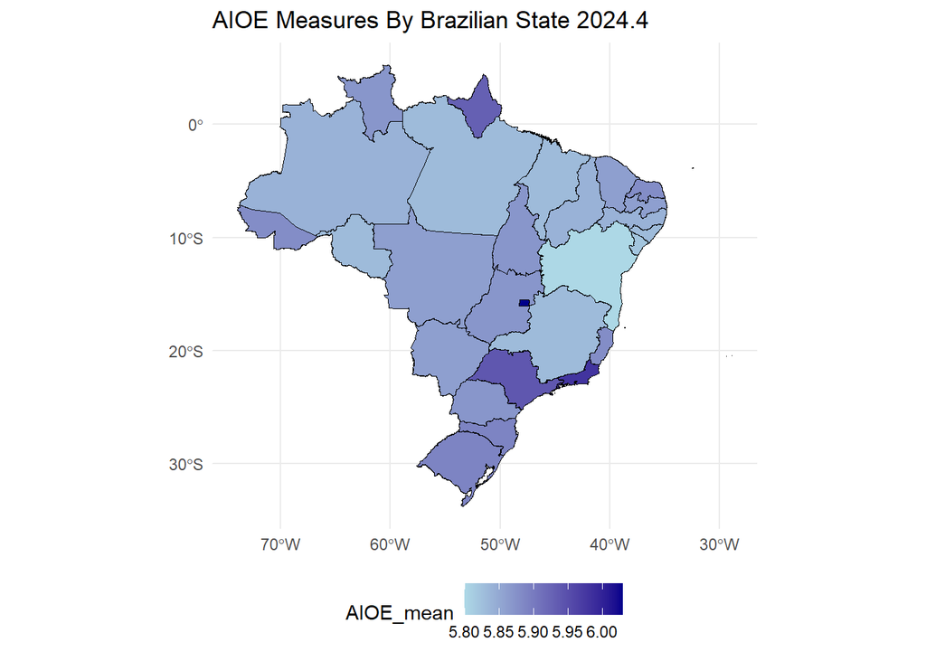

```r
plot_brazil_map_full_names(pnad_2024.4_AIOE_mean_by_state_round, state_col = 'UF', value_col = 'AIOE_mean')
```

```r
pnad_2024.4_AIOE_mean_by_state_formal <- dbGetQuery(con, 'SELECT UF, ROUND(MEAN(AIOE), 2) AS AIOE_mean FROM "pnad_2024.4_AIOE"  WHERE NOT V4029 IS NULL GROUP BY UF')
pnad_2024.4_AIOE_mean_by_state_informal <- dbGetQuery(con, 'SELECT UF, ROUND(MEAN(AIOE), 2) AS AIOE_mean FROM "pnad_2024.4_AIOE" WHERE V4029 IS NULL GROUP BY UF ')
formal_map <- plot_brazil_map_full_names(pnad_2024.4_AIOE_mean_by_state_formal, state_col = 'UF', value_col = 'AIOE_mean', title = "AIOE Measures - Formal", limits = c(5.73, 6.09))
```

```
## Using year/date 2010
```

```r
informal_map <- plot_brazil_map_full_names(pnad_2024.4_AIOE_mean_by_state_informal, state_col = 'UF', value_col = 'AIOE_mean', title = "AIOE Measures - Informal", limits = c(5.73, 6.09))
```

```
## Using year/date 2010
```

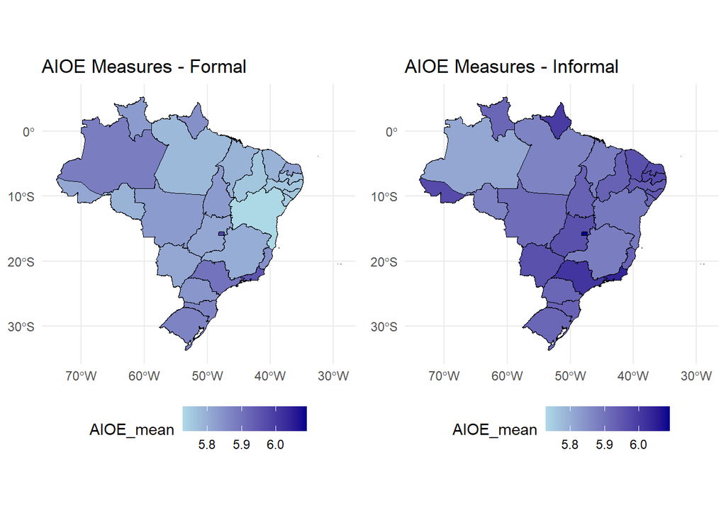

```r
grid.arrange(formal_map, informal_map, ncol=2)
```

```r
pnad_2024.4_AIOE_mean_by_state_capitals <- dbGetQuery(con, 'SELECT UF, ROUND(MEAN(AIOE), 2) AS AIOE_mean FROM "pnad_2024.4_AIOE"  WHERE V1023=\'Capital\' GROUP BY UF')
pnad_2024.4_AIOE_mean_by_state_not_capitals <- dbGetQuery(con, 'SELECT UF, ROUND(MEAN(AIOE), 2) AS AIOE_mean FROM "pnad_2024.4_AIOE" WHERE NOT V1023=\'Capital\' GROUP BY UF ')
Capital_map <- plot_brazil_map_full_names(pnad_2024.4_AIOE_mean_by_state_capitals, state_col = 'UF', value_col = 'AIOE_mean', title = "AIOE Measures - Capitals", limits = c(5.74, 6.17))
```

```
## Using year/date 2010
```

```r
not_capital_map <- plot_brazil_map_full_names(pnad_2024.4_AIOE_mean_by_state_not_capitals, state_col = 'UF', value_col = 'AIOE_mean', title = "AIOE Measures - Not Capitals", limits = c(5.74, 6.17))
```

```
## Using year/date 2010
```

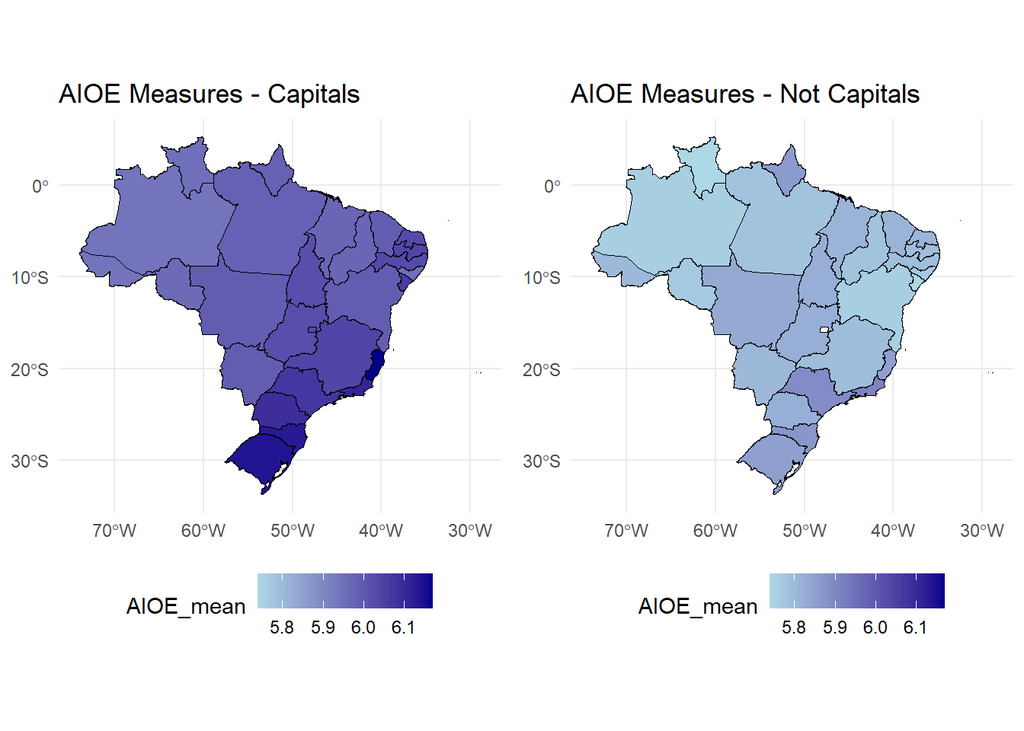

```r
grid.arrange(Capital_map, not_capital_map, ncol=2)
```

## Regression

Linear Regression for the salary_mean in terms of the Exposure Level (AIOE) mean controlling for formal share, male share, age mean and college share.

```r
summary(lm(salary_mean ~ AIOE_mean + formal_share + male_share + mean_age + college_share , data = pnad_2024.4_AIOE_mean_by_state))
```

```
##
## Call:
## lm(formula = salary_mean ~ AIOE_mean + formal_share + male_share +
##     mean_age + college_share, data = pnad_2024.4_AIOE_mean_by_state)
##
## Residuals:
##    Min     1Q Median     3Q    Max
## -711.9 -213.8 -100.6  202.3  710.8
##
## Coefficients:
##               Estimate Std. Error t value Pr(>|t|)
## (Intercept)   17007.97   27434.78   0.620  0.54197
## AIOE_mean     -3730.96    4672.45  -0.799  0.43352
## formal_share    451.38    1654.57   0.273  0.78767
## male_share    -2569.19    6098.78  -0.421  0.67784
## mean_age        147.18      87.23   1.687  0.10634
## college_share 11714.51    3999.26   2.929  0.00802 **
## ---
## Signif. codes:  0 '***' 0.001 '**' 0.01 '*' 0.05 '.' 0.1 ' ' 1
##
## Residual standard error: 393.4 on 21 degrees of freedom
## Multiple R-squared:  0.7552, Adjusted R-squared:  0.6969
## F-statistic: 12.95 on 5 and 21 DF,  p-value: 7.938e-06
```